# Conventions, Code and Data Management

2019-04-10

## Packages

```r
library(usethis)
library(devtools)
library(gapminder)
library(nycflights13)
library(tidyverse)
```

## Code Style

- The slides in the course contain a number of style and syntax conventions.
- Code styles and syntax can vary
- Be consistent

## Capitals vs lower case

- Everything in lower case
- I use `snake_case`
- Many people use `camelCase`

```r
gapminder %>% names
```

```
## [1] "country"   "continent" "year"      "lifeExp"   "pop"       "gdpPercap"
```

```r
flights %>% names
```

```
##  [1] "year"           "month"          "day"            "dep_time"
##  [5] "sched_dep_time" "dep_delay"      "arr_time"       "sched_arr_time"
##  [9] "arr_delay"      "carrier"        "flight"         "tailnum"
## [13] "origin"         "dest"           "air_time"       "distance"
## [17] "hour"           "minute"         "time_hour"
```

## Printing a tbl_df

```r
table <- tibble("a_is_a_variable" = c(1:5), "b_is_another_variable" = rnorm(5))
table
```

```
## # A tibble: 5 x 2
##   a_is_a_variable b_is_another_variable
##             <int>                 <dbl>
## 1               1                 1.20
## 2               2                -0.705
## 3               3                 0.452
## 4               4                -0.792
## 5               5                 1.82
```

## Variables

- All lower case
- Don't use capitals and special characters in file names

"`excel_file_of_important_dataset.xlsx`"

DON'T: "`data file + version 12_11_2017%.xlsx`"

## Packages referrals

Names of R packages are indicated as:

- mostly: `{dplyr}`
- sometimes: {dplyr}
- not often: "dplyr"

## Explicit functions

When we want to be explicit about a certain function in a package:

`dplyr::filter()`

Refers to the `filter()` function in the package `{dplyr}`

## Loose code in the slides

Sometimes a few lines of codes are displayed for demo purpose:

`four_numbers <- c(1:4)`

`multiply <- 4*four_numbers`

`sum(multiply^2)`

## Code blocks

Code blocks in slides are indicated as below: The result of the code is usually also displayed

[figure not shown]

```r
set.seed(1234)
code_that_does_something <- rnorm(1000)
hist(code_that_does_something, main = "rnorm")
```

## Hiding code

Sometimes it makes sense to hide the code and only display the result. This can be done by setting the code chunk options `echo = FALSE`

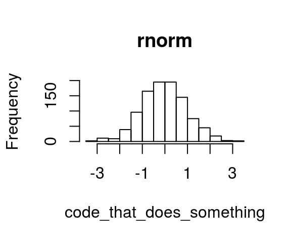

## Other important chunk options

- Like hiding the code, we can hide the result of that code and only display the code by setting `results = "hide"`
- Setting `eval = FALSE` means the chunk is not included in the slide show at all
- Setting `include = FALSE` means the chunk is run and the results are evaluated, but both the code and the results are not included in the slide-show/document
- Controlling settings for the complete document can be done in the `setup*` chunk that you will find in all Rmarkdown files from the course

```r
 knitr::opts_chunk$set(echo = TRUE,
                       message = FALSE,
                       warning = FALSE,
                       error = TRUE,
                       fig.width = 5, fig.height = 3)
```

- There are many chunk options. Some we will see in later lessons